# Example Summer School

Sinika Timme

8/20/2021

# 1 Description

Project Hexo Skin

The HexoSkin project examines physiological and psychological variables during PE lessons. With the help of smart shirts (HexoSkin) physiological parameters (e.g. breathing_rate; minute_ventilation, acceleration, HR, cadence) were collected during PE lessons. Every ten minutes pupils were asked how they currently feel (affect).

Current data sata

Measurements have been carried out in three schools with a total of 31 subjects so far. 12 participants from Zurich, 11 from Nauen and 8 from Potsdam. Each session has 8 time points of affect, while the physiological parameters were recorded every second. In Zurich, the 11 subjects took part at 4 different sessions. In total there were 6 sessions (see Fig. 1).

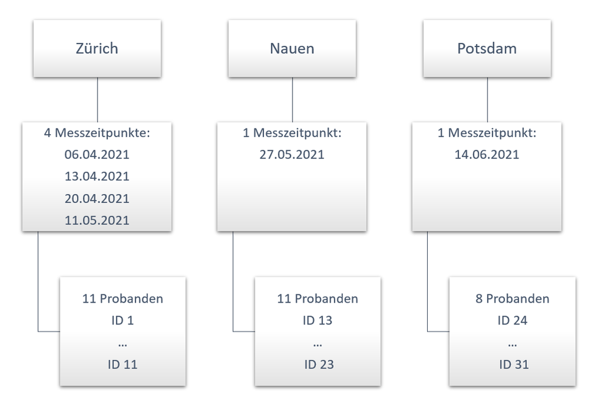

Abb. 1

# 2 This script

- Graphs of the Affect data

# 3 Psychological responses

## 3.1 Affect

### 3.1.1 Plotting

Individual Data

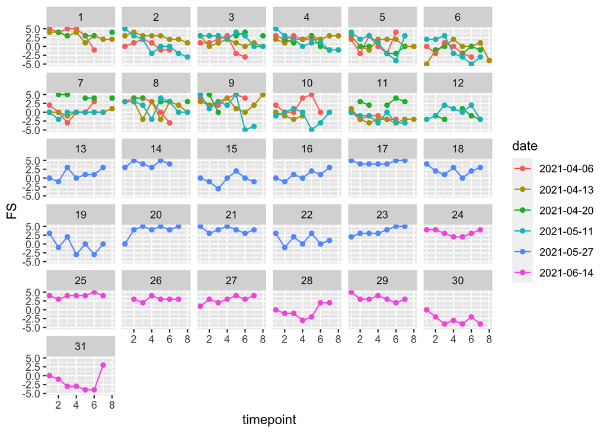

Mean growth pattern across individuals on the different time points

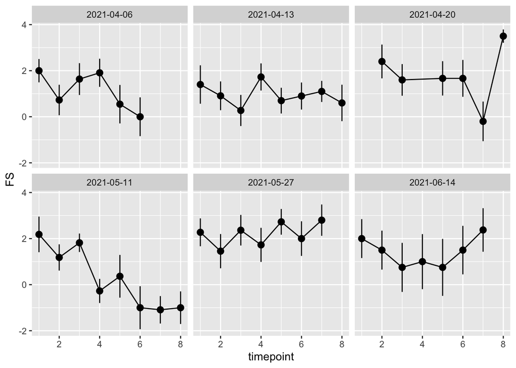

Mean growth pattern across individuals and time points

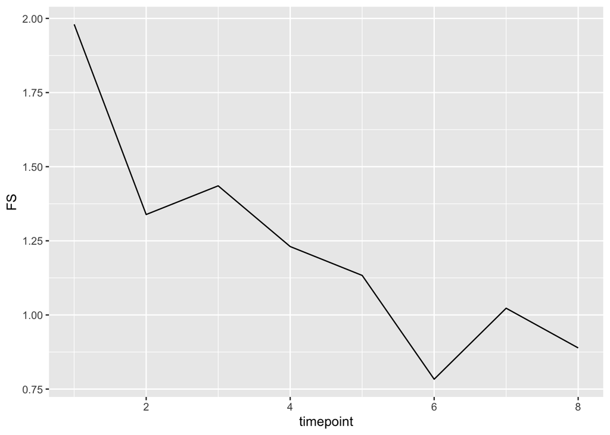

### 3.1.2 Data Analaysis

We are interested in the variability of the affective response.

First describe the overall group pattern and then describe how individual participants differ from that pattern

```
## boundary (singular) fit: see ?isSingular
```

```
## Data: affect
## Models:
## m0a: FS ~ 1 + (1 | ID)
## m0b1: FS ~ 1 + (1 | ID) + (1 | date)
## m0b2: FS ~ 1 + (1 | ID) + (1 | school_ID)
## m0b3: FS ~ 1 + (1 | school_ID/ID)
## m0c: FS ~ 1 + (1 | ID) + (1 | date) + (1 | school_ID)
##      npar    AIC    BIC  logLik deviance  Chisq Df Pr(>Chisq)
## m0a     3 1751.7 1763.8 -872.87   1745.7
## m0b1    4 1747.5 1763.5 -869.74   1739.5 6.2614  1    0.01234 *
## m0b2    4 1753.7 1769.8 -872.87   1745.7 0.0000  0
## m0b3    4 1753.7 1769.8 -872.87   1745.7 0.0000  0
## m0c     5 1749.5 1769.5 -869.74   1739.5 6.2611  1    0.01234 *
## ---
## Signif. codes:  0 '***' 0.001 '**' 0.01 '*' 0.05 '.' 0.1 ' ' 1
```

Random Effect structure

- There is no significant variability in mean affect between schools, χ2(1) = 0.0003, p = 0.99, but between dates χ2(1) = 6.26, p = 0.01.

|  | FS |  |  |
| --- | --- | --- | --- |
| Predictors | Estimates | CI | p |
| (Intercept) | 1.45 | 0.70 – 2.20 | **<0.001** |
| Random Effects |  |  |  |
| σ<sup>2</sup> | 3.43 |  |  |
| τ<sub>00</sub> <sub>ID</sub> | 2.93 |  |  |
| τ<sub>00</sub> <sub>date</sub> | 0.20 |  |  |
| ICC | 0.48 |  |  |
| N <sub>ID</sub> | 31 |  |  |
| N <sub>date</sub> | 6 |  |  |
| Observations | 408 |  |  |
| Marginal R<sup>2</sup> / Conditional R<sup>2</sup> | 0.000 / 0.477 |  |  |

- There is a mean affect of 1.45 (95% CI: 0.70-2.20) on each date averaged over each child across all timepoints.
- Individuals vary around this grand mean by τ00 = 2.93. The sessions vary around the grand mean by τ00 = 0.20
- Individiuals vary around their own mean by σ2 = 3.43

ICC/Conditional R2: 48% of the variance lies between individuals, while 52% lies within individuals.

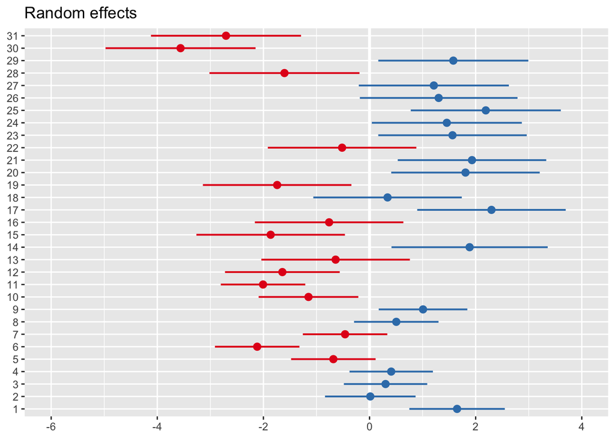

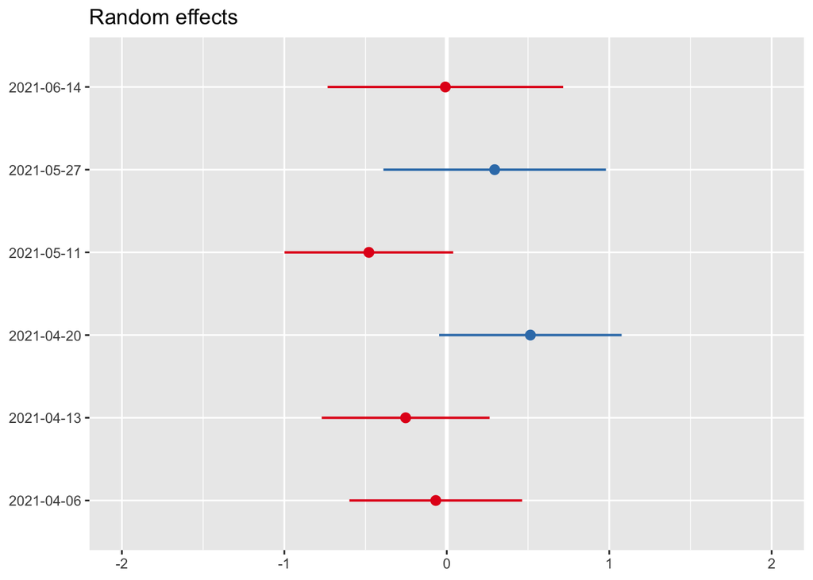

Questions:

- Which is the right random effect structure?
  - Do I need something like (1|school_ID/ID) to account for the nested data structure?
- Correct interpretation of the coefficient?
- How to calculate ICC for the different levels?

# 4 Model 1: with time variable

```
## Data: affect
## Models:
## m0b1: FS ~ 1 + (1 | ID) + (1 | date)
## m1b.1: FS ~ timepoint + (1 | ID) + (1 | date)
## m1b.2: FS ~ timepoint + (timepoint | ID) + (1 | date)
##       npar    AIC    BIC  logLik deviance   Chisq Df Pr(>Chisq)
## m0b1     4 1747.5 1763.5 -869.74   1739.5
## m1b.1    5 1737.6 1757.7 -863.81   1727.6 11.8582  1  0.0005741 ***
## m1b.2    7 1740.2 1768.3 -863.10   1726.2  1.4052  2  0.4953042
## ---
## Signif. codes:  0 '***' 0.001 '**' 0.01 '*' 0.05 '.' 0.1 ' ' 1
```

There is a significant effect of time , but not signficant interindividual variablity in the affect slopes over time of individuals.

# 5 Physiological responses

## 5.1 Heart Rate

|  | HR |  |  |
| --- | --- | --- | --- |
| Predictors | Estimates | CI | p |
| (Intercept) | 129.19 | 120.44 – 137.95 | **<0.001** |
| Random Effects |  |  |  |
| σ<sup>2</sup> | 714.03 |  |  |
| τ<sub>00</sub> <sub>ID</sub> | 338.71 |  |  |
| τ<sub>00</sub> <sub>date</sub> | 43.09 |  |  |
| ICC | 0.35 |  |  |
| N <sub>ID</sub> | 30 |  |  |
| N <sub>date</sub> | 6 |  |  |
| Observations | 290855 |  |  |
| Marginal R<sup>2</sup> / Conditional R<sup>2</sup> | 0.000 / 0.348 |  |  |

# 6 Combining psychological and physiological responses

*How to deal with the fact that we have sampled physiological responses every second and psychological responses every 10 minutes?*

```r
FS.HR <- lmer(FS~ HR + (1|ID) + (1|date), REML = FALSE, data = hexaff_all)
tab_model(FS.HR)
```

|  | FS |  |  |
| --- | --- | --- | --- |
| Predictors | Estimates | CI | p |
| (Intercept) | 2.09 | 1.25 – 2.94 | **<0.001** |
| HR | -0.01 | -0.01 – -0.01 | **<0.001** |
| Random Effects |  |  |  |
| σ<sup>2</sup> | 3.13 |  |  |
| τ<sub>00</sub> <sub>ID</sub> | 3.80 |  |  |
| τ<sub>00</sub> <sub>date</sub> | 0.28 |  |  |
| ICC | 0.57 |  |  |
| N <sub>ID</sub> | 30 |  |  |
| N <sub>date</sub> | 6 |  |  |
| Observations | 242976 |  |  |
| Marginal R<sup>2</sup> / Conditional R<sup>2</sup> | 0.004 / 0.568 |  |  |

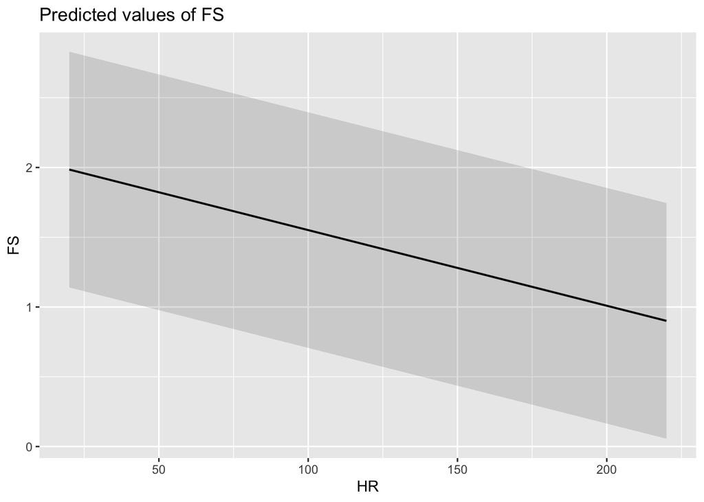

```r
plot_model(FS.HR, type = "pred")
```

I think I need to aggregate the HR data and take the mean for each timepoint when affect was measured?!

```r
hexaff_all_agg <- hexaff_all %>% group_by(ID, timepoint, date) %>% summarize(M_FS = mean(FS, na.rm = TRUE), M_HR = mean(HR, na.rm = TRUE))
FS.HR.agg <- lmer(M_FS~ M_HR + (1|ID) + (1|date), REML = FALSE, data = hexaff_all_agg)
tab_model(FS.HR.agg)
```

|  | M FS |  |  |
| --- | --- | --- | --- |
| Predictors | Estimates | CI | p |
| (Intercept) | 3.05 | 1.52 – 4.57 | **<0.001** |
| M_HR | -0.01 | -0.02 – -0.00 | **0.013** |
| Random Effects |  |  |  |
| σ<sup>2</sup> | 3.38 |  |  |
| τ<sub>00</sub> <sub>ID</sub> | 3.22 |  |  |
| τ<sub>00</sub> <sub>date</sub> | 0.20 |  |  |
| ICC | 0.50 |  |  |
| N <sub>ID</sub> | 30 |  |  |
| N <sub>date</sub> | 6 |  |  |
| Observations | 388 |  |  |
| Marginal R<sup>2</sup> / Conditional R<sup>2</sup> | 0.016 / 0.511 |  |  |

```r
FS.HR.agg.RS <- lmer(M_FS~ M_HR + (M_HR|ID) + (1|date), REML = FALSE, data = hexaff_all_agg, control = lmerControl(calc.derivs = FALSE))
tab_model(FS.HR.agg.RS)
```

|  | M FS |  |  |
| --- | --- | --- | --- |
| Predictors | Estimates | CI | p |
| (Intercept) | 2.95 | 1.43 – 4.47 | **<0.001** |
| M_HR | -0.01 | -0.03 – 0.00 | 0.064 |
| Random Effects |  |  |  |
| σ<sup>2</sup> | 3.28 |  |  |
| τ<sub>00</sub> <sub>ID</sub> | 1.22 |  |  |
| τ<sub>00</sub> <sub>date</sub> | 0.28 |  |  |
| τ<sub>11</sub> <sub>ID.M_HR</sub> | 0.00 |  |  |
| ρ<sub>01</sub> <sub>ID</sub> | -0.67 |  |  |
| ICC | 0.55 |  |  |
| N <sub>ID</sub> | 30 |  |  |
| N <sub>date</sub> | 6 |  |  |
| Observations | 388 |  |  |
| Marginal R<sup>2</sup> / Conditional R<sup>2</sup> | 0.014 / 0.557 |  |  |

```r
anova(FS.HR.agg, FS.HR.agg.RS)
```

```
## Data: hexaff_all_agg
## Models:
## FS.HR.agg: M_FS ~ M_HR + (1 | ID) + (1 | date)
## FS.HR.agg.RS: M_FS ~ M_HR + (M_HR | ID) + (1 | date)
##              npar    AIC    BIC  logLik deviance  Chisq Df Pr(>Chisq)
## FS.HR.agg       5 1662.0 1681.8 -825.98   1652.0
## FS.HR.agg.RS    7 1659.6 1687.4 -822.82   1645.6 6.3333  2    0.04214 *
## ---
## Signif. codes:  0 '***' 0.001 '**' 0.01 '*' 0.05 '.' 0.1 ' ' 1
```